# Final Passages Data Visualization

Made with the help of tutorials from: https://towardsdatascience.com/lets-make-a-map-using-geopandas-pandas-and-matplotlib-to-make-a-chloropleth-map-dddc31c1983d

and https://towardsdatascience.com/data-visualization-simple-statistical-views-in-pandas-cf31d5fd4e39

## About the visualization

This project takes a collection of the total number of voyages between the Americas and compares this to voyages leaving Jamaica from the years 1652-1812. Jamaica is used in comparison because it was an area with a large amount of traffic to other places in the Americas.

Each visualization is represented by headings. Data in red represents voyages across the entire dataset, and data in orange represents voyages with their origin in Jamaica.

### In total, the data represent 11,401 voyages, with an estimated 446,000 enslaved people transported throughout the Americas. Of these, 3,048 voyages had their port of origin in Jamaica, with an estimated 133,100 enslaved people.

```python
# import statements

import numpy as np
import pandas as pd
import geopandas as gpd
import matplotlib.pyplot as plt
```

```python
# Load in CSV

df = pd.read_csv("data\Jamaica\Jamaica-VisualizationData.csv", header=0)

df = df[['voyageid','yearam','slaximp', 'mjselimp']]

dffull = pd.read_csv("data\FinalPassages8b-encoded.csv", header=0)

dffull = dffull[['voyageid','yearam','slaximp', 'mjselimp']]

data_for_map = df.rename(index=str, columns={"voyageid": "Voyage ID","yearam": "Voyage Year","slaximp": "Captives on Vessel","mjselimp" : "Arrival colony"})
```

## Number of captives in voyages by year

This represents the number of enslaved people being transported in each voyage. This ranged from 1 to 1,086 reported enslaved people being transported.

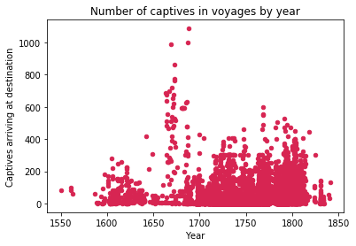

```python
dffull.plot.scatter(y='slaximp', x='yearam', color='#D72552')
plt.title('Number of captives in voyages by year')
plt.ylabel('Captives arriving at destination')
plt.xlabel('Year')
```

For voyages leaving Jamaica, voyages are concentrated between the years 1650s to 1820s, with the greatest number of captives on a vouage being 633 enslaved people.

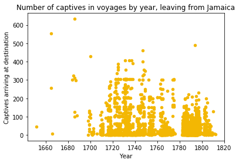

```python
df.plot.scatter(y='slaximp', x='yearam', color='#F3B703')
plt.title('Number of captives in voyages by year, leaving from Jamaica')
plt.ylabel('Captives arriving at destination')
plt.xlabel('Year')
```

# Number of voyages by year for most frequently occuring years

These graphs represent the number of voyages by year, showing the years that have that had the most voyages. Voyages happened the most frequently in the 1780s-90s, with almost 350 voyages taking place overall in 1790.

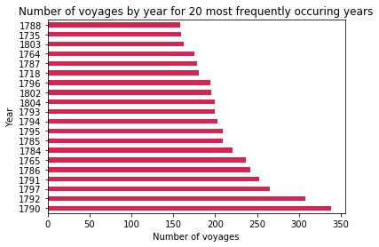

```python
dffull['yearam'].value_counts()[:20].plot(kind='barh', color='#D72552')
plt.title('Number of voyages by year for 20 most frequently occuring years')
plt.ylabel('Year')
plt.xlabel('Number of voyages')
```

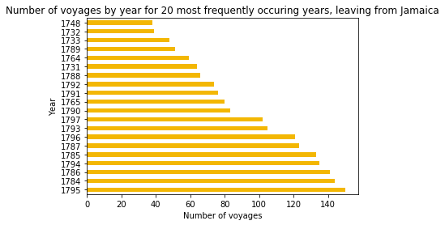

```python
df['yearam'].value_counts()[:20].plot(kind='barh', color='#F3B703')
plt.title('Number of voyages by year for 20 most frequently occuring years, leaving from Jamaica')
plt.ylabel('Year')
plt.xlabel('Number of voyages')
```

# Number of voyages by location for 20 most frequently occuring locations

The next two figures show the desfination location of voyages, with the orange graph representing only voyages departing from Jamaica. As seen here, Cuba was the largest destination across all voyages, and is heavily represented in the Jamaica dataset as well.

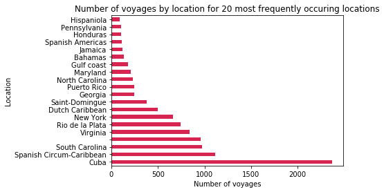

```python
dffull['mjselimp'].value_counts()[:20].plot(kind='barh', color='#D72552')
plt.title('Number of voyages by location for 20 most frequently occuring locations')
plt.ylabel('Location')
plt.xlabel('Number of voyages')
```

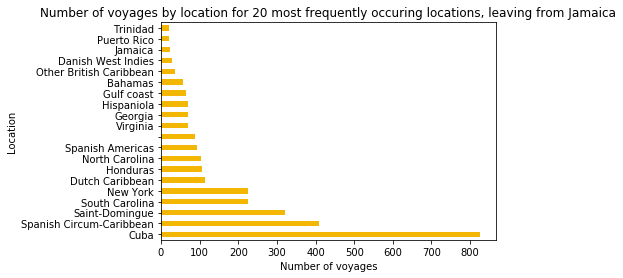

```python
df['mjselimp'].value_counts()[:20].plot(kind='barh', color='#F3B703')
plt.title('Number of voyages by location for 20 most frequently occuring locations, leaving from Jamaica')
plt.ylabel('Location')
plt.xlabel('Number of voyages')
```

## Map of voyage destinations from Jamaica

The next graphics show voyage destinations in map form for voyages leaving Jamaica.

Note that the map does not accurately represent all of the voyage data leaving Jamaica. For instance, voyages lableled with their destination as "Spanish Circum-Caribbean," which you can see is the second-most frequent location on the graph above, is not represented on the map because this is not a specific geographic location.

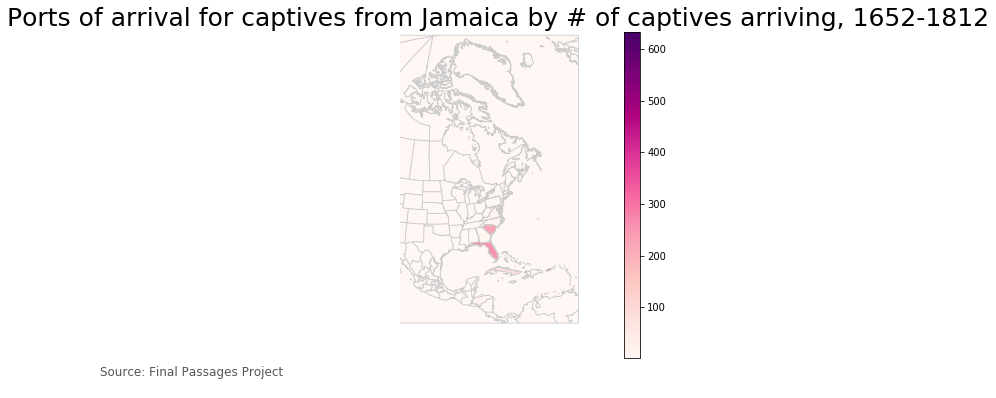

```python
# Displaying a map of voyages

# set the filepath and load in a shapefile

fp = "mapdata/boundary_p_v2.shp"

map_df = gpd.read_file(fp)

# check data type so we can see that this is not a normal dataframe, but a GEOdataframe

map_df.head()

# Now let’s preview what our map looks like with no data in it.

# map_df.plot()

df = pd.read_csv("data\Jamaica\jamaica.csv", header=0)


df = df[['voyageid','yearam','slaximp', 'mjselimp']]

data_for_map = df.rename(index=str, columns={"voyageid": "Voyage ID","yearam": "Voyage Year","slaximp": "Captives on Vessel","mjselimp" : "Arrival colony"})



df.head()

# check dat dataframe

data_for_map.head()

# join the geodataframe with the cleaned up csv dataframe

merged = map_df.set_index('NAME').join(data_for_map.set_index('Arrival colony'))

# merged.head()

# set a variable that will call whatever column we want to visualise on the map

variable = 'Captives on Vessel'

# set the range for the choropleth

vmin, vmax = 1, 633

# create figure and axes for Matplotlib



fig, ax = plt.subplots(1, figsize=(10, 6))

ax.set_xlim(-1000000, 5000000)
ax.set_ylim(-5000000, 5000000)

# create map

merged.plot(column=variable, cmap='RdPu', linewidth=0.8, ax=ax, edgecolor='0.8')

# remove the axis

ax.axis('off')

# add a title

ax.set_title('Ports of arrival for captives from Jamaica by # of captives arriving, 1652-1812', fontdict={'fontsize': '25', 'fontweight' : '3'})

# create an annotation for the data source

ax.annotate('Source: Final Passages Project',xy=(0.1, .08),  xycoords='figure fraction', horizontalalignment='left', verticalalignment='top', fontsize=12, color='#555555')

# Create colorbar as a legend

sm = plt.cm.ScalarMappable(cmap='RdPu', norm=plt.Normalize(vmin=vmin, vmax=vmax))

# empty array for the data range

sm._A = []

# add the colorbar to the figure

cbar = fig.colorbar(sm)
```